# 8. Visualização de dados

# 1 Diretório

# 2 Pacotes e dados

```r
library(rio)
library(tidyverse)
library(metan)

# set_wd_here("data")
# dados
df <- import("eucalipto.xlsx")
df_retangulo <-
  df |>
  mutate(col = rep(1:14, 5),
         row = rep(1:5, each = 14))
```

# 3 Gráficos

> “O gráfico simples trouxe mais informações à mente do analista de dados do que qualquer outro dispositivo.” — John Tukey

## 3.1 O pacote `ggplot2`

O `ggplot2` é um pacote R para produção de gráficos que diferentemente da maioria dos outros pacotes, apresenta uma profunda gramática baseada no livro *The grammar of graphics* (Wilkinson 2005)[^1]. Os gráficos originados em `ggplot2` são baseados em camadas, e cada gráfico tem três componentes chave: `data`, os dados de onde o gráfico será criado; `aes()` (*aesthetic mappings*), que controla o mapeamento estético e as propriedades visuais do gráfico; e ao menos uma camada que irá descrever como cada observação será renderizada. Camadas são usualmente criadas utilizando uma função `geom_()`.

## 3.2 Galerias

- https://www.r-graph-gallery.com/portfolio/ggplot2-package/
- http://r-statistics.co/Top50-Ggplot2-Visualizations-MasterList-R-Code.html
- https://r4stats.com/examples/graphics-ggplot2/
- http://girke.bioinformatics.ucr.edu/GEN242/pages/mydoc/Rgraphics.html

## 3.3 Extensões do `ggplot2`

- http://www.ggplot2-exts.org/gallery/
- https://mode.com/blog/r-ggplot-extension-packages

## 3.4 Tutoriais em português

- https://rpubs.com/mnunes/ggplot2
- https://analisereal.com/2015/09/19/introducao-ao-ggplot2/
- https://timogrossenbacher.ch/2016/12/beautiful-thematic-maps-with-ggplot2-only/
- http://recologia.com.br/tag/graficos/
- http://rstudio-pubs-static.s3.amazonaws.com/24563_3b7b0a6414824e3b91769a95309380f1.html
- http://eduardogutierres.com/inteligencia-geografica-gerando-mapas-em-r/
- https://pt.stackoverflow.com/questions/332053/r-mapa-de-cidades-brasileiras

## 3.5 Meu primeiro gráfico em `ggplot2`

A seguir, vamos discutir os aspcetos básicos para a construção de gráficos utilizando o pacote `ggplot2`. A função `arrange_ggplot()` do pacote `metan` é utilizada aqui para organizar os gráficos em forma de painéis.

## 3.6 As camadas de um gráfico `ggplot2`

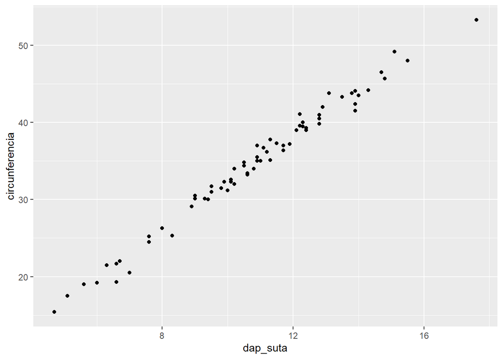

```r
p1 <-
  ggplot(df, aes(x = dap_suta, y = circunferencia)) +
  geom_point()
p1
```

Este comando criou um gráfico e armazenou no objeto `p1`, que será plotado posteriormente. Observe que o primeiro argumento da função é o data frame onde nossos dados foram armazenados. A função `aes()` descreve como as variáveis são mapeadas (neste caso `dap_suta` no eixo `x` e `circunferencia` no eixo `y`). A função `geom_point()` definiu que a forma geométrica a ser utilizada é baseada em pontos, gerando, assim, um gráfico de dispersão. Isto é tudo que precisa ser feito para a confecção de um gráfico simples.

## 3.7 Aesthetics (estética)

> “O maior valor de uma imagem é quando ela nos obriga a perceber o que nunca esperamos ver.” — John Tukey

Alterar a estética dos gráficos `ggplot2` é uma tarefa relativamente simples. No gráfico anterior, os valores do `dap_suta` e `circunferencia` foram plotados sem nenhum tipo de mapeamento estético. Digamos que marcadores com diferentes cores para cada nível do fator `fila` poderia nos ajudar a compreender melhor o padrão presente em nossos dados. Vamos confeccionar este gráfico.

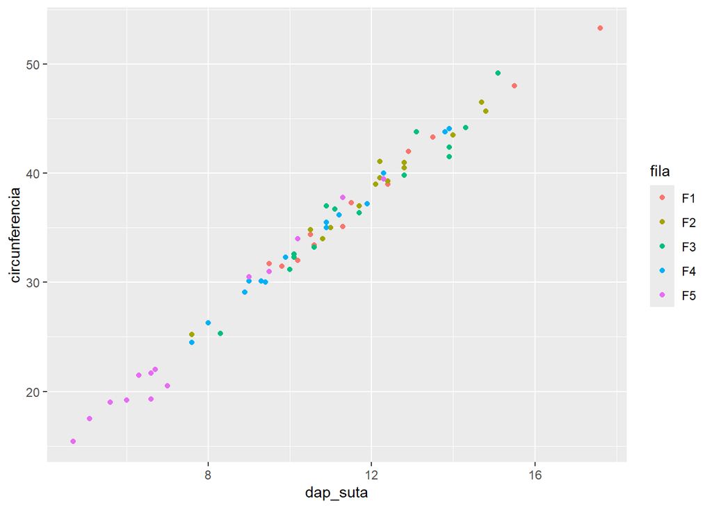

```r
p2 <-
  ggplot(df, aes(x = dap_suta, y = circunferencia, color = fila)) +
  geom_point()
p2
```

Ao incluirmos `color = fila` dentro da função `aes`, dizemos ao `ggplot` que os pontos devem ser mapeados esteticamente (neste caso utilizando cores) para cada nível do fator `fila` presente em nossos dados. Digamos que em vez de utilizar diferentes cores, cada fila deveria ser representada por diferentes tipos de marcadores (quadrados, triângulo, etc.) Neste caso, o argumento `colour = fila` é substituído por `shape = fila`.

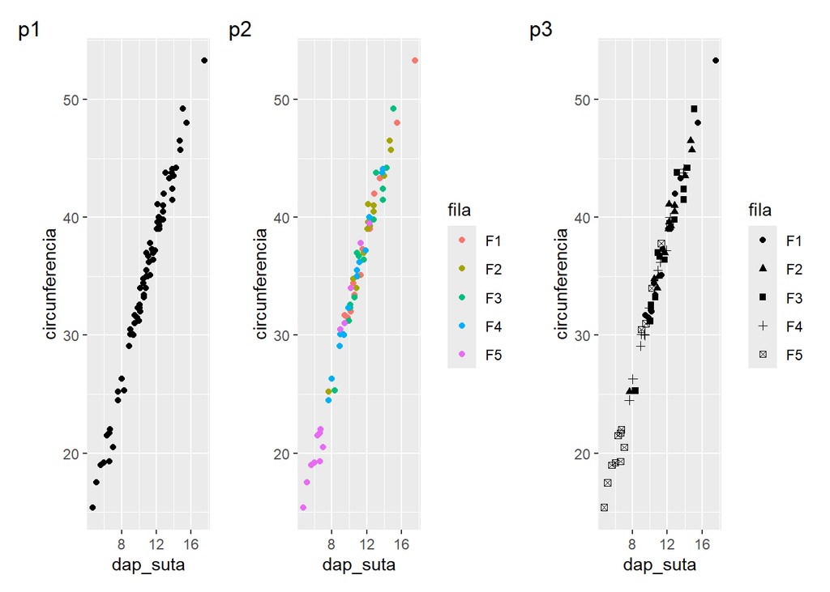

```r
p3 <-
  ggplot(df, aes(x = dap_suta,
                 y = circunferencia,
                 shape = fila)) +
  geom_point()


# organizar os gráficos
arrange_ggplot(p1, p2, p3,
               ncol = 3,
               tag_levels = list(c("p1", "p2", "p3")))
```

## 3.8 Salvar gráficos

A função `ggsave()` é uma função conveniente para salvar um gráfico. O padrão é salvar a última plotagem exibida, usando o tamanho do dispositivo gráfico atual. Também é possível informar a altura (`height`) e circunferencia (`width`). Ele também adivinha o tipo de dispositivo gráfico da extensão. No seguinte exemplo, o gráfico acima é salvo no diretório de trabalho atual com o nome `pontos.png`, com 5 polegadas de altura e 10 de circunferencia.

```r
ggsave("pontos.png",
       height = 5,
       width = 10)
```

## 3.9 Facet (facetas)

Mapeando os diferentes níveis de `cor` para diferentes cores, incluímos em um único gráfico os dados de todos osgrupos. Mas, e se nosso objetivo fosse realizar um gráfico para cada grupo? O `ggplot2` tem uma poderosa ferramenta para isto: as funções `facet_`. Ao utilizar estas funções, o conjunto de dados é subdividido e um gráfico é construído para cada um destes subconjuntos. Vamos ver como elas podem nos ajudar em nosso problema.

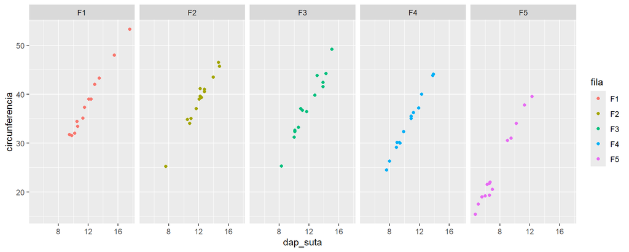

Um painel para cada nível da variável grupo.

```r
fac1 <-
  ggplot(df, aes(x = dap_suta,
                 y = circunferencia,
                 color = fila)) +
  geom_point() +
  facet_wrap(~ fila, ncol = 5)
fac1
```

Neste exemplo, um gráfico completamente diferente do anterior é gerado com apenas uma simples adição: incluímos uma nova função, `facet_wrap(~ fila)`. Neste caso, informamos que um gráfico deveria ser realizado para cada grupo.

## 3.10 Theme (temas)

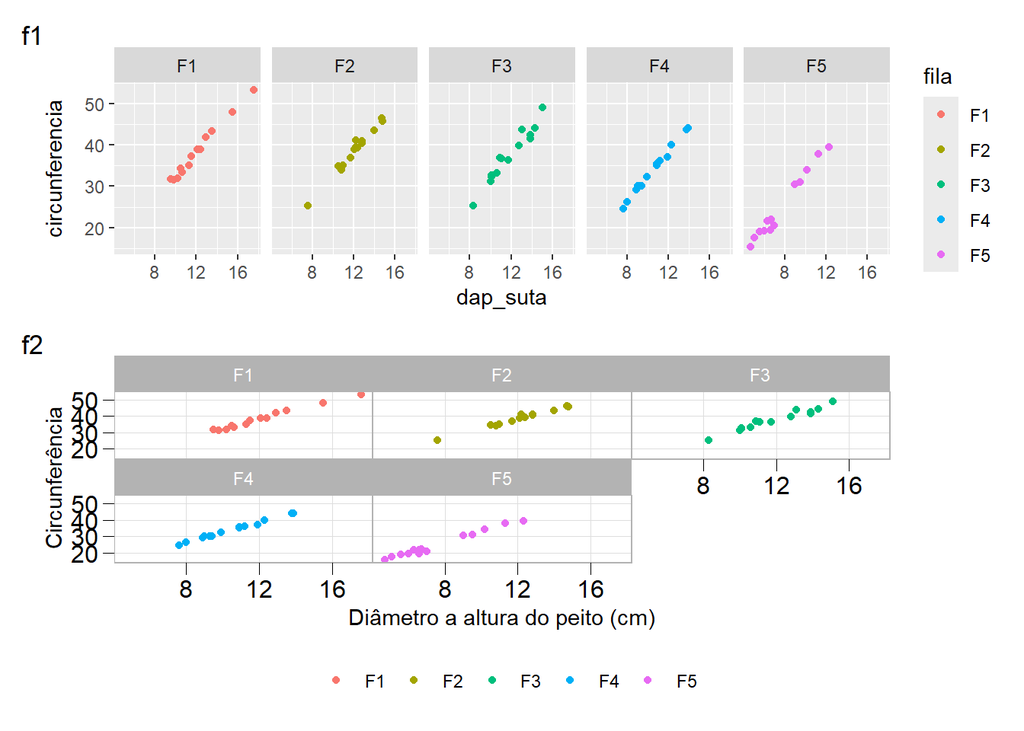

Gráfico de dispersão considerando a confecção de um gráfico para cada nível de um fator(f1) e modificações na propriedades do tema de um gráfico ggplot2 (f2)

```r
fac2 <-
  ggplot(df, aes(x = dap_suta, y = circunferencia, color = fila)) +
  geom_point() +
  facet_wrap(~ fila) +
  theme_light() +
  theme(panel.grid.minor = element_blank(), # remove as linhas do corpo do gráfico
        # sem bordas entre os painéis
        panel.spacing = unit(0, "cm"),
        # legenda abaixo do gráfico
        legend.position = "bottom",
        # modifica o texto dos eixos
        axis.text = element_text(size = 12, colour = "black"),
        # cor dos marcadores
        axis.ticks = element_line(colour = "black"),
        # tamanho dos marcadores
        axis.ticks.length = unit(.2, "cm"))+
  # título dos eixos
  labs(x = "Diâmetro a altura do peito (cm)", # título do eixo x
       y = "Circunferência", # título do eixo y
       color = "") # título da legenda

arrange_ggplot(fac1, fac2,
               ncol = 1,
               tag_levels = list(c("f1", "f2")))
```

Os argumentos inseridos dentro das função `theme()` modificaram a aparência do nosso gráfico. Inúmeros outros argumentos são disponíveis, fazendo com que os gráficos originados sejam completamente personalizáveis. Digamos que precisamos confeccionar diversos gráficos e gostaríamos de manter o mesmo tema do gráfico acima. Seria exaustivo e desinteressante informar cada vez estes argumentos para cada gráfico, não? Felizmente, outra poderosa ferramenta proporcionada pelo `ggplot2` é a possibilidade de confeccionarmos nossos próprios temas. Para isto, vamos executar o seguinte comando para criar um tema personalizado (`my_theme()`). Este tema pode então ser aplicado como uma camada adicional a cada gráfico que confecionarmos. Para evitar a necessidade da inclusão deste tema em cada gráfico gerado, iremos definir este tema como padrão utilizando a função `theme_set()`.

```r
my_theme <- function () {
  theme_light() %+replace% # permite que os valores informados possam ser sobescritos
    theme(axis.ticks.length = unit(.2, "cm"),
          axis.text = element_text(size = 12, colour = "black"),
          axis.title = element_text(size = 12, colour = "black"),
          axis.ticks = element_line(colour = "black"),
          panel.border = element_rect(colour = "black", fill = NA, size = 0.5),
          panel.grid.minor =  element_blank())
}
theme_set(my_theme())
```

## 3.11 Geoms (geometria)

As funções `geom_` definem qual forma geométrica será utilizada para a visualização dos dados no gráfico. Até agora, utilizamos a função `geom_point()`para construir gráficos de dispersão. Basicamente, qualquer outro tipo de gráfico pode ser criado dependendo da função `geom_` utilizada. Dentre as diversas disponíveis no pacote `ggplot2` as funções `geom_` mais utilizadas são:

- `geom_abline()`: para retas definidas por um intercepto e uma inclinação;
- `geom_hline()`: para retas horizontais definidas por um intercept `y`;
- `geom_vline()`: para retas verticais definidas por um intercept `x`;
- `geom_boxplot()`: para boxplots;
- `geom_histogram()`: para histogramas de frequência;
- `geom_smooth()`: ajusta uma função para o conjunto de dados e mostra uma banda de confiança;
- `geom_density()`: para densidades;
- `geom_area()`: para áreas;
- `geom_bar()`: para barras;
- `geom_errorbar()` para barras de erro;

Deste ponto em diante, vamos confeccionar alguns exemplos utilizando algumas destas funções (ou combinações destas funções) incluindo argumentos de mapeamento de estética e temas vistos até agora.

### 3.11.1 Linhas horizontais, verticais e diagonais

Três importantes geometrias são apresentadas a seguir:

1. `geom_hline()` adiciona uma linha horizontal definida por um intercepto em `y`
2. `geom_vline()` adiciona uma linha vertical definida por um intercepto em `x`.
3. `geom_abline()` adiciona uma linha diagonal definida por um intercepto e uma inclinação.

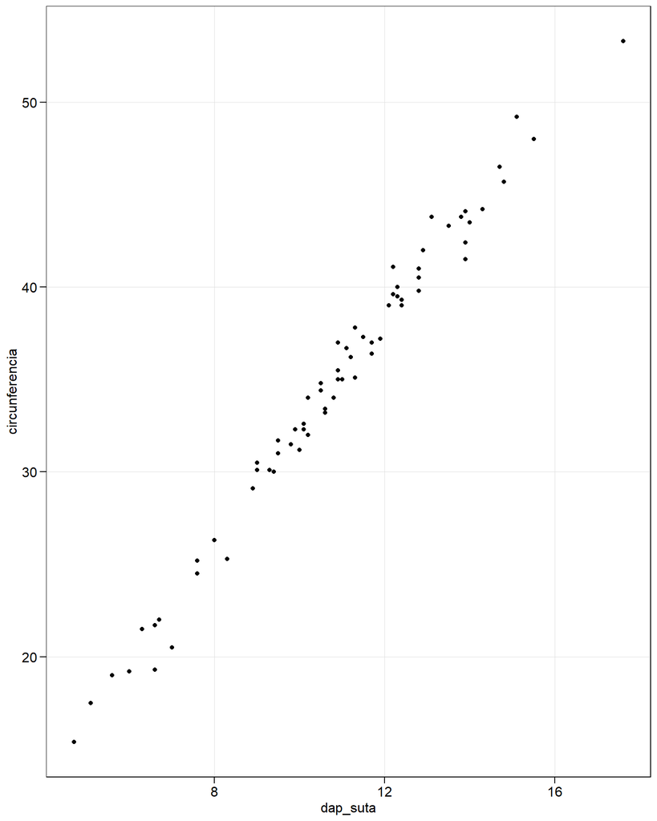

```r
g1 <-
  ggplot(df, aes(dap_suta, circunferencia)) +
  geom_point()
g1
```

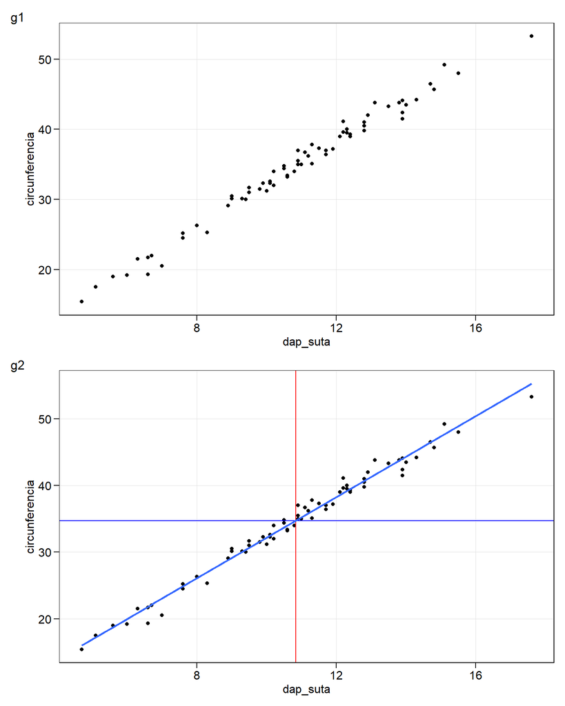

```r
# adiciona linhas horizontais e verticais
g2 <-
  g1 +
  geom_hline(yintercept = mean(df$circunferencia), color = "blue") +
  geom_vline(xintercept = mean(df$dap_suta), color = "red") +
  geom_smooth(method = "lm", se = FALSE)

arrange_ggplot(g1, g2,
               ncol = 1,
               tag_levels = list(c("g1", "g2")))
```

### 3.11.2 Gráficos do tipo boxplot

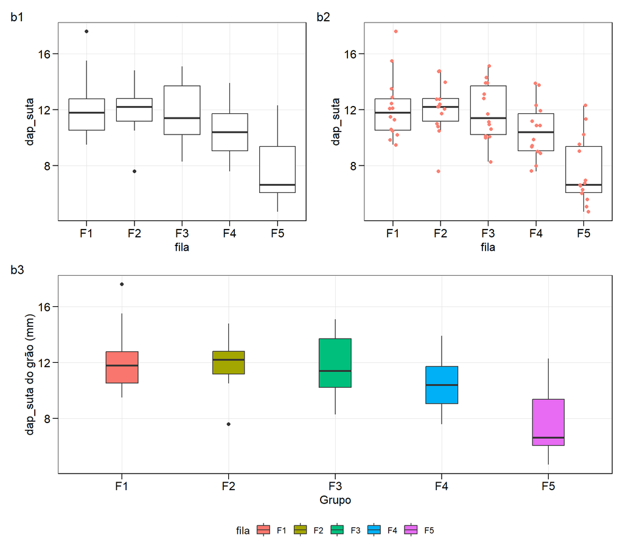

Gráfico do tipo boxplot combinando mapeamentos estéticos.

```r
box1 <-
  ggplot(df, aes(fila, dap_suta)) +
  geom_boxplot()

box2 <-
  ggplot(df, aes(fila, dap_suta)) +
  geom_boxplot(outlier.colour = "transparent") +
  geom_jitter(width = 0.1, color = "salmon")

box3 <-
  ggplot(df, aes(fila, dap_suta, fill = fila)) +
  geom_boxplot(width = 0.3) +
  labs(x = "Grupo",
       y = "dap_suta do grão (mm)") +
  theme(legend.position = "bottom")

arrange_ggplot((box1 + box2) / box3,
               tag_levels = list(c("b1", "b2", "b3")))
```

### 3.11.3 Gráficos do tipo barra

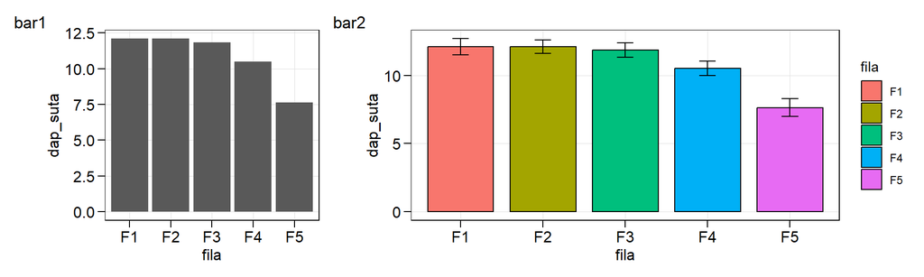

Gráfico do tipo barras, com mapeamento estético e barras de erro.

```r
bar1 <-
  ggplot(df, aes(x = fila, y = dap_suta)) +
  geom_bar(stat = "summary", fun = "mean")

bar2 <-
  ggplot(df, aes(x = fila, y = dap_suta, fill = fila)) +
  stat_summary(fun = mean,
               geom = "bar",
               col = "black",
               width = 0.8,
               position = position_dodge(0.8)) +
  stat_summary(fun.data = mean_se,
               geom = "errorbar",
               width = 0.2,
               position = position_dodge(0.8))


arrange_ggplot(bar1, bar2,
               widths = c(0.6, 1.2),
               tag_levels = list(c("bar1", "bar2")))
```

A afirmação de que um gráfico `ggplot2` é feito em camadas fica mais evidente aqui. No gráfico `bar1`, as barras representam as médias geral do `dap_suta` para cada grupo. No segundo gráfico, ao usar `fill = fila` informamos que as barras devem ser coloridas para cada nível do fator `fila`. A função `stat_summary()`, é vista pela primeira vez aqui, foi utilizada no segundo gráfico para substituir a função `geom_bar()`. Com isto, foi possível incluir as médias (`fun = mean` e `geom = "bar`), bem como as barras de erro (`fun.data = mean_se` e `geom = "errorbar"`).

### 3.11.4 Gráficos do tipo histograma e densidade

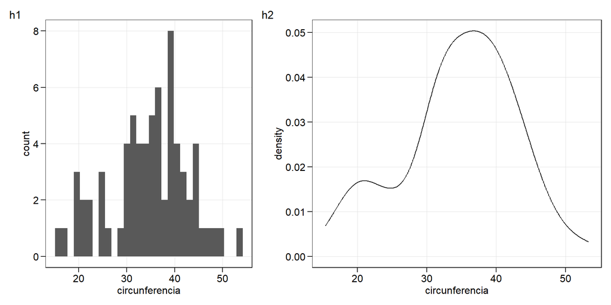

Gráfico do tipo histograma

```r
h1 <-
  ggplot(df, aes(x = circunferencia)) +
  geom_histogram()

d1 <-
  ggplot(df, aes(x = circunferencia)) +
  geom_density()

arrange_ggplot(h1, d1,
               widths = c(1, 1.4),
               tag_levels = list(c("h1", "h2")))
```

## 3.12 Mapas

### 3.12.1 Mapa da américa do sul e Brasil

O pacote `rnaturalearth` é uma excelente ferramenta para manter e facilitar a interação com os dados do mapa [Natural Earth](https://www.naturalearthdata.com/). Para produção de mapas com o `ggplot2`, os seguintes pacotes são necessários.

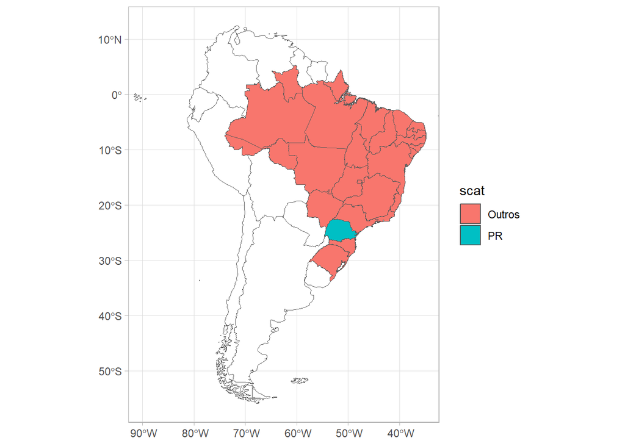

```r
#| out-width: "100%"


# américa do sul
library(rnaturalearth)
library(tidyverse)
sam <-
  ne_countries(continent = "south america",
               returnclass = "sf",
               scale = 50)

p1 <-
  ggplot() +
  geom_sf(data = sam, fill = "white") +
  theme_light() +
  xlim(c(-90, -35))

# plotar o brasil e destacar santa catarina
brazil <-
  ne_states(country = "brazil", returnclass = "sf") |>
  mutate(scat = ifelse(postal == "PR", "PR", "Outros"))

p2 <-
  p1 +
  geom_sf(data = brazil, aes(fill = scat))
p2
```

```r
library(geobr)


pr <-
  read_municipality(code_muni = "PR",
                    simplified = FALSE,
                    showProgress = FALSE) |>
  mutate(Curitiba = ifelse(name_muni == "Curitiba",
                          "Curitiba",
                          "Outro"))
```

```
Using year/date 2010
```

[figure not shown]

```r
p3 <-
  p1 +
  geom_sf(data = brazil) +
  geom_sf(data = pr, aes(fill = Curitiba)) +
  xlim(c(-55, -47)) +
  ylim(c(-28, -22)) +
  labs(title = "Mapa do brasil destacando o estado de SC",
       caption = "Produzido com os pkgs geobr e rnaturalearth",
       fill = "") +
  theme(legend.position = "bottom")
p3
```